# DATA 607 – Project 3: Most Valued Data Science Skills

Lakeranie Boodram, Johnny Maldonado, Dylan DiTucci-Cappiello

2026-10-18

## 1. Introduction

The purpose of this project is to investigate which technical skills are most valued by employers hiring data science professionals.

Our group examined LinkedIn job posting data from 2023 and 2024 to identify frequently requested skills such as Python, SQL, R, machine learning, Tableau, Power BI, and cloud computing.

We also compared skill requirements across data analysts, data scientists, and data engineers.

Our analysis included data cleaning, relational database management using SQLite, exploratory data analysis, and data visualizations in R.

Our main research question is:

**Which data science skills are most valued by employers?**

## 2. Loading Required Libraries

We used R packages to import, clean, organize, store, and analyze our data. These packages also allowed us to create visualizations and manage our relational database.

```r
# Load the libraries needed for this project

library(tidyverse)
library(DBI)
library(RSQLite)
library(readxl)
library(knitr)
```

## 3. Dataset Source and Scope

We originally downloaded the LinkedIn job postings dataset from Kaggle and filtered it to focus on Data Analyst, Data Scientist, and Data Engineer positions. After filtering the data, we saved the smaller dataset to GitHub so it would be easier for our group to access and reproduce the analysis.

```r
# Load the filtered LinkedIn job postings from GitHub


data_url <- paste0(
  "https://raw.githubusercontent.com/LBoodram26/",
  "Project-3/Data/"
)

data_jobs <- read_csv(
  paste0(data_url, "data_jobs.csv"),
  show_col_types = FALSE,
  col_types = cols(job_id = col_character())
)

# Confirm the dataset loaded
dim(data_jobs)
```

```
## [1] 1052    7
```

## 4. Importing the Filtered Dataset from GitHub

Our filtered LinkedIn dataset has been uploaded to GitHub. We imported the CSV directly into R to make the analysis accessible and reproducible for all group members.

```r
# Check the number of rows and columns
dim(data_jobs)
```

```
## [1] 1052    7
```

```r
# Preview the first six records
head(data_jobs)
```

```
## # A tibble: 6 × 7
##   job_id     company_name       title location company_id formatted_experience…¹
##   <chr>      <chr>              <chr> <chr>         <dbl> <chr>
## 1 3742692445 ZenithMinds Inc    Sr D… Austin,…   81941852 <NA>
## 2 3797449314 Subaru Research a… Clou… Michiga…   91080439 Entry level
## 3 3800989742 SilverSpace Techn… Data… Hartfor…   71373471 <NA>
## 4 3813645405 Tenazx Inc         Data… Queens,…   82537206 <NA>
## 5 3841003722 <NA>               Seni… Califor…         NA <NA>
## 6 3872787865 Radiant Systems I… eCom… United …    3342169 <NA>
## # ℹ abbreviated name: ¹formatted_experience_level
## # ℹ 1 more variable: skills_desc <chr>
```

```r
# Display the column names
names(data_jobs)
```

```
## [1] "job_id"                     "company_name"
## [3] "title"                      "location"
## [5] "company_id"                 "formatted_experience_level"
## [7] "skills_desc"
```

## 5. Data Cleaning and Quality Checks

Before performing our analysis, we examined the dataset for missing values and duplicate records. This helped us understand the quality of the data and identify what needed to be cleaned.

We also reviewed the job titles and experience levels to make sure the information was consistent before creating our relational database.

### 5.1 Checking Missing Values

```r
# Count missing values in each column

missing_values <- data_jobs %>%
  summarise(across(
    everything(),
    ~ sum(is.na(.))
  ))

# Display the results
knitr::kable(missing_values)
```

| job_id | company_name | title | location | company_id | formatted_experience_level | skills_desc |
| --- | --- | --- | --- | --- | --- | --- |
| 0 | 10 | 0 | 0 | 10 | 295 | 1043 |

### 5.2 Checking Duplicate Records

```r
# Check the number of duplicate job IDs

duplicate_jobs <- sum(duplicated(data_jobs$job_id))

# Display the result
duplicate_jobs
```

```
## [1] 0
```

### 5.3 Reviewing Experience Levels

```r
# Count job postings by experience level

experience_summary <- data_jobs %>%
  count(formatted_experience_level, sort = TRUE)

# Display the results
knitr::kable(experience_summary)
```

| formatted_experience_level | n |
| --- | --- |
| Mid-Senior level | 443 |
| NA | 295 |
| Entry level | 227 |
| Associate | 68 |
| Director | 12 |
| Internship | 5 |
| Executive | 2 |

### 5.4 Cleaning and Standardizing the Data

After reviewing the missing values and experience levels, we prepared the dataset for our analysis. We remove duplicate job IDs, standardize the job categories, and label missing experience levels as “Not Specified.”

We kept records with missing skill descriptions because we used supplementary skill data from Kaggle.

```r
# Clean and standardize the job posting data

data_jobs_clean <- data_jobs %>%
  distinct(job_id, .keep_all = TRUE) %>%
  mutate(
    job_category = case_when(
      str_detect(str_to_lower(title), "data scientist") ~ "Data Scientist",
      str_detect(str_to_lower(title), "data engineer") ~ "Data Engineer",
      str_detect(str_to_lower(title), "data analyst") ~ "Data Analyst",
      TRUE ~ "Other"
    ),
    experience_level = if_else(
      is.na(formatted_experience_level),
      "Not Specified",
      formatted_experience_level
    )
  )

# Check the cleaned job categories
data_jobs_clean %>%
  count(job_category)
```

```
## # A tibble: 3 × 2
##   job_category       n
##   <chr>          <int>
## 1 Data Analyst     407
## 2 Data Engineer    398
## 3 Data Scientist   247
```

```r
# Confirm the total number of records
nrow(data_jobs_clean)
```

```
## [1] 1052
```

## 6. Creating a Relational Database

We used SQLite to organize our cleaned job posting data into normalized relational tables. Instead of storing the same company and location information repeatedly, we separated the data into related tables and connect them using primary and foreign keys.

We used the DBI and RSQLite packages to create and manage our database.

### 6.1 Setting Up the Database

```r
# Create the database folder
dir.create("database", showWarnings = FALSE)

# Create the database connection
con <- dbConnect(
  SQLite(),
  "database/data_science_skills.sqlite"
)

# Enable foreign key constraints
dbExecute(con, "PRAGMA foreign_keys = ON")
```

```
## [1] 0
```

```r
# Remove existing tables before rebuilding
# Delete child tables before parent tables
dbExecute(con, "DROP TABLE IF EXISTS Posting_Skills")
```

```
## [1] 0
```

```r
dbExecute(con, "DROP TABLE IF EXISTS Skills")
```

```
## [1] 0
```

```r
dbExecute(con, "DROP TABLE IF EXISTS Job_Postings")
```

```
## [1] 0
```

```r
dbExecute(con, "DROP TABLE IF EXISTS Locations")
```

```
## [1] 0
```

```r
dbExecute(con, "DROP TABLE IF EXISTS Companies")
```

```
## [1] 0
```

```r
# Verify connection
dbIsValid(con)
```

```
## [1] TRUE
```

### 6.2 Creating Normalized Relational Tables

We separated the cleaned job posting data into relational tables for companies, locations, and job postings.

The Companies table stores company information, while the Locations table stores unique job locations. The Job_Postings table contains the individual postings and connect them to the other tables using foreign keys.

This structure reduces repeated information and help maintain consistency in our database.

```r
# Create a table containing unique companies

companies <- data_jobs_clean %>%
  filter(!is.na(company_name)) %>%
  distinct(company_name) %>%
  arrange(company_name) %>%
  mutate(company_key = row_number()) %>%
  select(company_key, company_name)

# Create the Companies table with a primary key
dbExecute(con, "
  CREATE TABLE IF NOT EXISTS Companies (
    company_key INTEGER PRIMARY KEY,
    company_name TEXT NOT NULL UNIQUE
  )
")
```

```
## [1] 0
```

```r
# Insert company records
dbWriteTable(
  con,
  "Companies",
  companies,
  append = TRUE
)

# Check the records
head(companies)
```

```
## # A tibble: 6 × 2
##   company_key company_name
##         <int> <chr>
## 1           1 100K Job Hunt
## 2           2 1st-Recruit LLC, An E-Verified Company
## 3           3 3M
## 4           4 4A IT Services LLC
## 5           5 4D Molecular Therapeutics
## 6           6 A-Line Staffing Solutions
```

```r
# Create a table containing unique locations

locations <- data_jobs_clean %>%
  filter(!is.na(location)) %>%
  distinct(location) %>%
  arrange(location) %>%
  mutate(location_key = row_number()) %>%
  select(location_key, location)

# Create the Locations table with a primary key
dbExecute(con, "
  CREATE TABLE IF NOT EXISTS Locations (
    location_key INTEGER PRIMARY KEY,
    location TEXT NOT NULL UNIQUE
  )
")
```

```
## [1] 0
```

```r
# Insert location records
dbWriteTable(
  con,
  "Locations",
  locations,
  append = TRUE
)

# Check the records
head(locations)
```

```
## # A tibble: 6 × 2
##   location_key location
##          <int> <chr>
## 1            1 Akron, OH
## 2            2 Alameda, CA
## 3            3 Alexandria, VA
## 4            4 Allentown, PA
## 5            5 Alpharetta, GA
## 6            6 Anaheim, CA
```

```r
# Connect job postings with the company and location tables

job_postings <- data_jobs_clean %>%
  left_join(companies, by = "company_name") %>%
  left_join(locations, by = "location") %>%
  transmute(
    job_id = as.character(job_id),
    company_key,
    location_key,
    title,
    job_category,
    experience_level
  )

# Create the Job_Postings table with foreign keys
dbExecute(con, "
  CREATE TABLE IF NOT EXISTS Job_Postings (
    job_id TEXT PRIMARY KEY,
    company_key INTEGER,
    location_key INTEGER,
    title TEXT,
    job_category TEXT,
    experience_level TEXT,
    FOREIGN KEY (company_key)
      REFERENCES Companies(company_key),
    FOREIGN KEY (location_key)
      REFERENCES Locations(location_key)
  )
")
```

```
## [1] 0
```

```r
# Insert job posting records
dbWriteTable(
  con,
  "Job_Postings",
  job_postings,
  append = TRUE
)

# Preview the records
head(job_postings)
```

```
## # A tibble: 6 × 6
##   job_id     company_key location_key title        job_category experience_level
##   <chr>            <int>        <int> <chr>        <chr>        <chr>
## 1 3742692445         631           19 Sr Data Eng… Data Engine… Not Specified
## 2 3797449314         511          179 Cloud Platf… Data Engine… Entry level
## 3 3800989742         487          125 Data Engine… Data Engine… Not Specified
## 4 3813645405         547          230 Data Analyst Data Analyst Not Specified
## 5 3841003722          NA           44 Senior Data… Data Engine… Not Specified
## 6 3872787865         442          285 eCommerce D… Data Analyst Not Specified
```

### 6.3 Checking Database Tables

```r
# List the tables created in SQLite
dbListTables(con)
```

```
## [1] "Companies"    "Job_Postings" "Locations"
```

```r
# Count records stored in each table
dbGetQuery(con, "
  SELECT 'Companies' AS table_name, COUNT(*) AS records
  FROM Companies
  UNION ALL
  SELECT 'Locations', COUNT(*)
  FROM Locations
  UNION ALL
  SELECT 'Job_Postings', COUNT(*)
  FROM Job_Postings
")
```

```
##     table_name records
## 1    Companies     648
## 2    Locations     314
## 3 Job_Postings    1052
```

### 6.4 Verifying Database Relationships

After creating the relational tables, we checked whether the job postings can be connected to their company and location information.

We used SQL JOIN statements to retrieve information from multiple tables. This helps us confirm that our primary and foreign keys are working correctly.

```r
# Join job postings with companies and locations

joined_jobs <- dbGetQuery(con, "
  SELECT
    j.job_id,
    j.title,
    j.job_category,
    c.company_name,
    l.location,
    j.experience_level
  FROM Job_Postings AS j
  LEFT JOIN Companies AS c
    ON j.company_key = c.company_key
  LEFT JOIN Locations AS l
    ON j.location_key = l.location_key
  LIMIT 10
")

# Display the results
knitr::kable(joined_jobs)
```

| job_id | title | job_category | company_name | location | experience_level |
| --- | --- | --- | --- | --- | --- |
| 3742692445 | Sr Data Engineer with Kafka | Data Engineer | ZenithMinds Inc | Austin, TX | Not Specified |
| 3797449314 | Cloud Platform/ Big Data Engineer | Data Engineer | Subaru Research and Development, Inc | Michigan, United States | Entry level |
| 3800989742 | Data Engineer/ETL | Data Engineer | SilverSpace Technologies Inc | Hartford, CT | Not Specified |
| 3813645405 | Data Analyst | Data Analyst | Tenazx Inc | Queens, NY | Not Specified |
| 3841003722 | Senior Data Engineer/Analyst - Full Time | Data Engineer | NA | California, United States | Not Specified |
| 3872787865 | eCommerce Data Analyst | Data Analyst | Radiant Systems Inc | United States | Not Specified |
| 3884426975 | Azure Data Engineer (Full time) | Data Engineer | Publicis Sapient | Arlington, VA | Mid-Senior level |
| 3884431580 | Azure Data Engineer | Data Engineer | Econtenti, Inc | Seattle, WA | Not Specified |
| 3884432522 | Wealth Management Business Data Analyst | Data Analyst | MCubeSoft | Charlotte, NC | Not Specified |
| 3884434664 | GCP Data Engineer (Only W2) | Data Engineer | TechWish | Sterling, VA | Mid-Senior level |

```r
# Check for foreign key violations

foreign_key_check <- dbGetQuery(
  con,
  "PRAGMA foreign_key_check"
)

# Display results
foreign_key_check
```

```
## [1] table  rowid  parent fkid
## <0 rows> (or 0-length row.names)
```

## 7. Importing and Organizing Skill Data

We imported two additional files from the LinkedIn dataset. The job_skills.csv file connects job postings with skill codes, while skills.csv provides the names of those skill categories.

We matched the skill records to our filtered job postings and prepare them for our relational database.

### 7.1 Importing the Supplementary Files

```r
# Import the supplementary LinkedIn datasets from GitHub

job_skills <- read_csv(
  paste0(data_url, "job_skills.csv"),
  show_col_types = FALSE,
  col_types = cols(job_id = col_character())
)

skills <- read_csv(
  paste0(data_url, "skills.csv"),
  show_col_types = FALSE
)

# Check the dataset dimensions
dim(job_skills)
```

```
## [1] 213768      2
```

```r
dim(skills)
```

```
## [1] 35  2
```

```r
# Preview the files
head(job_skills)
```

```
## # A tibble: 6 × 2
##   job_id     skill_abr
##   <chr>      <chr>
## 1 3884428798 MRKT
## 2 3884428798 PR
## 3 3884428798 WRT
## 4 3887473071 SALE
## 5 3887465684 FIN
## 6 3887465684 SALE
```

```r
head(skills)
```

```
## # A tibble: 6 × 2
##   skill_abr skill_name
##   <chr>     <chr>
## 1 ART       Art/Creative
## 2 DSGN      Design
## 3 ADVR      Advertising
## 4 PRDM      Product Management
## 5 DIST      Distribution
## 6 EDU       Education
```

### 7.2 Matching Skills to Job Postings

We matched job IDs from the skill dataset with the job IDs in our cleaned job posting dataset. This allows us to keep only the skill records relevant to our research.

We also checked for duplicate relationships and confirmed that the skill codes have matching descriptions.

```r
# Keep only skills associated with our cleaned jobs
job_skills_filtered <- job_skills %>%
  semi_join(
    data_jobs_clean %>%
      select(job_id),
    by = "job_id"
  ) %>%
  distinct(job_id, skill_abr)

# Match skill codes with their category names
job_skills_named <- job_skills_filtered %>%
  left_join(skills, by = "skill_abr")

# Verify the matched records
nrow(job_skills_filtered)
```

```
## [1] 1555
```

```r
n_distinct(job_skills_filtered$job_id)
```

```
## [1] 1034
```

```r
# Check missing skill names
sum(is.na(job_skills_named$skill_name))
```

```
## [1] 0
```

```r
# Preview the results
knitr::kable(head(job_skills_named, 10))
```

| job_id | skill_abr | skill_name |
| --- | --- | --- |
| 3884432522 | FIN | Finance |
| 3884432522 | SALE | Sales |
| 3884431580 | IT | Information Technology |
| 3884426975 | IT | Information Technology |
| 3887499080 | IT | Information Technology |
| 3884435224 | IT | Information Technology |
| 3884434664 | IT | Information Technology |
| 3884917966 | ENG | Engineering |
| 3884917966 | IT | Information Technology |
| 3887705985 | ENG | Engineering |

### 7.3 Creating the Skills and Posting_Skills Tables

We created two additional relational tables in SQLite. The Skills table stores unique skill categories, while the Posting_Skills table connects job postings with their associated skill categories.

This establishes a many-to-many relationship between job postings and skills while reducing duplicate information.

```r
# Create a table of unique skill categories

skills_table <- skills %>%
  distinct(skill_abr, skill_name) %>%
  filter(!is.na(skill_abr), !is.na(skill_name))

# Create the Skills table
dbExecute(con, "
  CREATE TABLE IF NOT EXISTS Skills (
    skill_abr TEXT PRIMARY KEY,
    skill_name TEXT NOT NULL
  )
")
```

```
## [1] 0
```

```r
# Insert the skill categories
dbWriteTable(
  con,
  "Skills",
  skills_table,
  append = TRUE
)

# Verify the number of records
dbGetQuery(con, "SELECT COUNT(*) AS total_skills FROM Skills")
```

```
##   total_skills
## 1           35
```

```r
# Prepare the linking table

posting_skills_table <- job_skills_filtered %>%
  distinct(job_id, skill_abr) %>%
  filter(!is.na(job_id), !is.na(skill_abr))

# Create the many-to-many linking table
dbExecute(con, "
  CREATE TABLE IF NOT EXISTS Posting_Skills (
    job_id TEXT NOT NULL,
    skill_abr TEXT NOT NULL,
    PRIMARY KEY (job_id, skill_abr),
    FOREIGN KEY (job_id) REFERENCES Job_Postings(job_id),
    FOREIGN KEY (skill_abr) REFERENCES Skills(skill_abr)
  )
")
```

```
## [1] 0
```

```r
# Insert the matching records
dbWriteTable(
  con,
  "Posting_Skills",
  posting_skills_table,
  append = TRUE
)

# Check the total relationships
dbGetQuery(con, "
  SELECT COUNT(*) AS total_relationships
  FROM Posting_Skills
")
```

```
##   total_relationships
## 1                1555
```

```r
# Display all database tables
dbListTables(con)
```

```
## [1] "Companies"      "Job_Postings"   "Locations"      "Posting_Skills"
## [5] "Skills"
```

```r
# Check the number of records in each table
table_summary <- dbGetQuery(con, "
  SELECT 'Companies' AS table_name, COUNT(*) AS records FROM Companies
  UNION ALL
  SELECT 'Locations', COUNT(*) FROM Locations
  UNION ALL
  SELECT 'Job_Postings', COUNT(*) FROM Job_Postings
  UNION ALL
  SELECT 'Skills', COUNT(*) FROM Skills
  UNION ALL
  SELECT 'Posting_Skills', COUNT(*) FROM Posting_Skills
")

knitr::kable(table_summary)
```

| table_name | records |
| --- | --- |
| Companies | 648 |
| Locations | 314 |
| Job_Postings | 1052 |
| Skills | 35 |
| Posting_Skills | 1555 |

```r
# Check for broken foreign key references
dbGetQuery(con, "PRAGMA foreign_key_check")
```

```
## [1] table  rowid  parent fkid
## <0 rows> (or 0-length row.names)
```

## 8. Exploratory Data Analysis

We used exploratory data analysis to examine patterns in the LinkedIn job posting dataset. Our goal is to identify which skill categories appear most frequently and compare how these requirements vary across data science job roles.

We used SQL to retrieve information from our relational database and R to summarize and visualize the results.

### 8.1 Calculating Skill Category Demand

```r
# Calculate the frequency of each skill category

skill_frequency <- dbGetQuery(con, "
  SELECT
    s.skill_name,
    COUNT(DISTINCT ps.job_id) AS job_count
  FROM Posting_Skills AS ps
  INNER JOIN Skills AS s
    ON ps.skill_abr = s.skill_abr
  GROUP BY s.skill_name
  ORDER BY job_count DESC
")

# Calculate percentages using all 1,052 postings
skill_frequency <- skill_frequency %>%
  mutate(
    percentage = round(job_count / nrow(data_jobs_clean) * 100, 1)
  )

# Display the results
knitr::kable(skill_frequency)
```

| skill_name | job_count | percentage |
| --- | --- | --- |
| Information Technology | 810 | 77.0 |
| Engineering | 308 | 29.3 |
| Analyst | 173 | 16.4 |
| Research | 70 | 6.7 |
| Other | 47 | 4.5 |
| Finance | 18 | 1.7 |
| Consulting | 14 | 1.3 |
| Science | 12 | 1.1 |
| Marketing | 11 | 1.0 |
| Quality Assurance | 10 | 1.0 |
| Business Development | 10 | 1.0 |
| Strategy/Planning | 9 | 0.9 |
| Product Management | 9 | 0.9 |
| Administrative | 9 | 0.9 |
| Management | 8 | 0.8 |
| Sales | 7 | 0.7 |
| Project Management | 5 | 0.5 |
| Human Resources | 5 | 0.5 |
| General Business | 5 | 0.5 |
| Design | 3 | 0.3 |
| Supply Chain | 2 | 0.2 |
| Legal | 2 | 0.2 |
| Health Care Provider | 2 | 0.2 |
| Advertising | 2 | 0.2 |
| Training | 1 | 0.1 |
| Manufacturing | 1 | 0.1 |
| Customer Service | 1 | 0.1 |
| Accounting/Auditing | 1 | 0.1 |

### 8.2 Visualizing Skill Category Demand

To better understand which skill categories appear most frequently in the LinkedIn job postings, we created a horizontal bar chart.

The chart displays the percentage of job postings associated with each skill category. This helps us identify the most common skill requirements and make comparisons between categories.

We used ggplot2 to create the visualization.

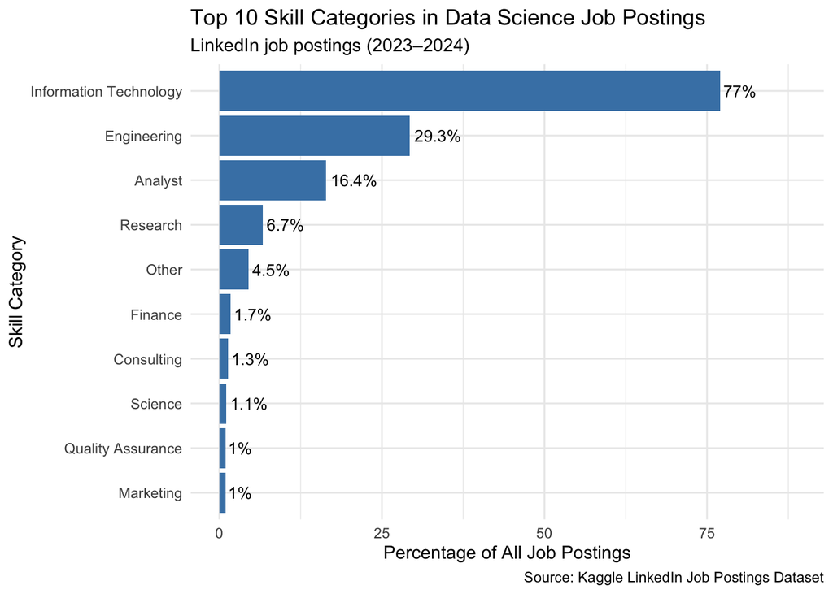

```r
# Select the 10 most frequently listed skill categories
top_skills <- skill_frequency %>%
  arrange(desc(job_count)) %>%
  slice_head(n = 10)

# Create a horizontal bar chart
ggplot(
  top_skills,
  aes(
    x = reorder(skill_name, percentage),
    y = percentage
  )
) +
  geom_col(fill = "steelblue") +
  geom_text(
    aes(label = paste0(percentage, "%")),
    hjust = -0.1,
    size = 3.5
  ) +
  coord_flip() +
  scale_y_continuous(
    limits = c(0, max(top_skills$percentage) * 1.15)
  ) +
  labs(
    title = "Top 10 Skill Categories in Data Science Job Postings",
    subtitle = "LinkedIn job postings (2023–2024)",
    x = "Skill Category",
    y = "Percentage of All Job Postings",
    caption = "Source: Kaggle LinkedIn Job Postings Dataset"
  ) +
  theme_minimal()
```

### 8.3 Comparing Skill Categories Across Job Roles

We compared skill category requirements across Data Analyst, Data Scientist, and Data Engineer positions.

This analysis helps us identify differences in employer requirements based on job role. We calculated the percentage of postings mentioning each skill category within each role.

```r
# Calculate skill category demand by job role

role_skill_summary <- dbGetQuery(con, "
  SELECT
    j.job_category,
    s.skill_name,
    COUNT(DISTINCT ps.job_id) AS job_count
  FROM Job_Postings AS j
  INNER JOIN Posting_Skills AS ps
    ON j.job_id = ps.job_id
  INNER JOIN Skills AS s
    ON ps.skill_abr = s.skill_abr
  GROUP BY j.job_category, s.skill_name
")

# Calculate total postings in each job category
role_totals <- dbGetQuery(con, "
  SELECT
    job_category,
    COUNT(*) AS total_jobs
  FROM Job_Postings
  GROUP BY job_category
")

# Calculate percentages within each job category
role_skill_summary <- role_skill_summary %>%
  left_join(role_totals, by = "job_category") %>%
  mutate(
    percentage = round(job_count / total_jobs * 100, 1)
  )

# Display the results
knitr::kable(head(role_skill_summary, 15))
```

| job_category | skill_name | job_count | total_jobs | percentage |
| --- | --- | --- | --- | --- |
| Data Analyst | Accounting/Auditing | 1 | 407 | 0.2 |
| Data Analyst | Administrative | 6 | 407 | 1.5 |
| Data Analyst | Advertising | 2 | 407 | 0.5 |
| Data Analyst | Analyst | 138 | 407 | 33.9 |
| Data Analyst | Business Development | 5 | 407 | 1.2 |
| Data Analyst | Consulting | 3 | 407 | 0.7 |
| Data Analyst | Customer Service | 1 | 407 | 0.2 |
| Data Analyst | Engineering | 46 | 407 | 11.3 |
| Data Analyst | Finance | 12 | 407 | 2.9 |
| Data Analyst | General Business | 2 | 407 | 0.5 |
| Data Analyst | Health Care Provider | 1 | 407 | 0.2 |
| Data Analyst | Human Resources | 2 | 407 | 0.5 |
| Data Analyst | Information Technology | 286 | 407 | 70.3 |
| Data Analyst | Legal | 1 | 407 | 0.2 |
| Data Analyst | Management | 3 | 407 | 0.7 |

### 8.4 Visualizing Skill Categories by Job Role

We created a grouped bar chart to compare skill categories across Data Analyst, Data Scientist, and Data Engineer positions.

This helps us identify how frequently different skill categories appear within each job role and highlight differences in employer requirements.

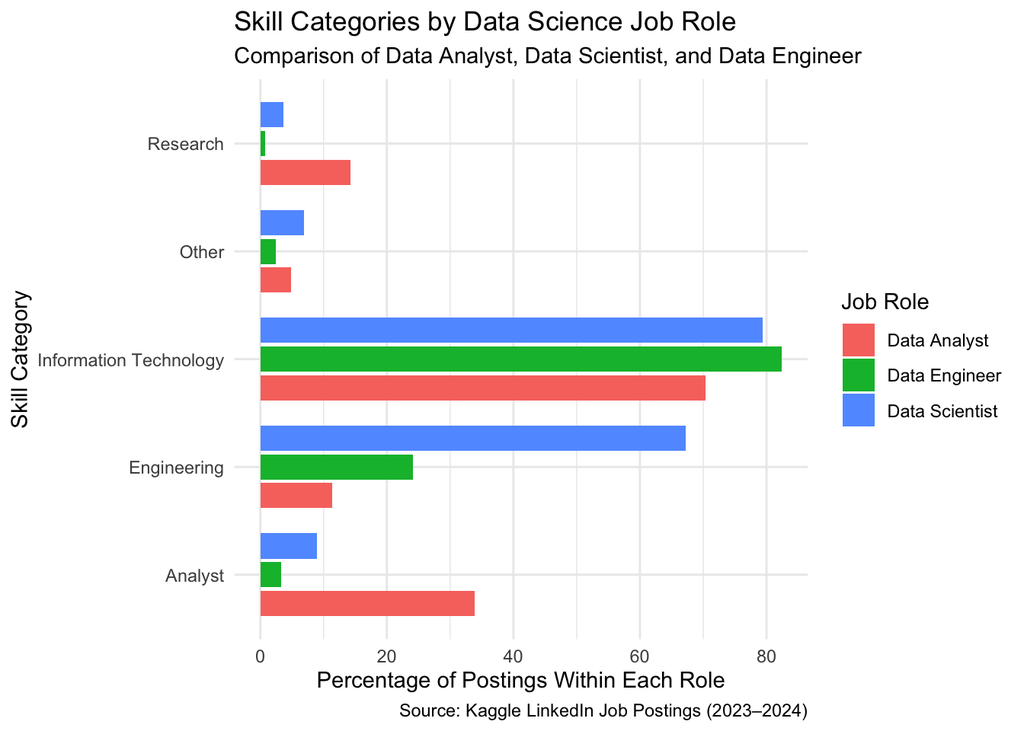

```r
# Select the five most common skill categories overall

top_five_skills <- skill_frequency %>%
  arrange(desc(job_count)) %>%
  slice_head(n = 5) %>%
  pull(skill_name)

# Filter the role comparison data
role_skill_plot <- role_skill_summary %>%
  filter(skill_name %in% top_five_skills) %>%
  select(job_category, skill_name, percentage)

# Create a grouped bar chart
ggplot(
  role_skill_plot,
  aes(
    x = skill_name,
    y = percentage,
    fill = job_category
  )
) +
  geom_col(
    position = position_dodge(width = 0.8),
    width = 0.7
  ) +
  coord_flip() +
  labs(
    title = "Skill Categories by Data Science Job Role",
    subtitle = "Comparison of Data Analyst, Data Scientist, and Data Engineer",
    x = "Skill Category",
    y = "Percentage of Postings Within Each Role",
    fill = "Job Role",
    caption = "Source: Kaggle LinkedIn Job Postings (2023–2024)"
  ) +
  theme_minimal()
```

## 9. Identifying Specific Technical Skills

Although the supplementary skill files provide general skill categories, our research focuses on specific technical skills.

We examined job descriptions to identify mentions of technologies such as Python, SQL, R, machine learning, Tableau, Power BI, and cloud platforms.

This allows us to compare technical skill requirements across different data science job roles.

### 9.1 Checking Available Job Descriptions

```r
# Check whether the original dataset is available
exists("postings")
```

```
## [1] FALSE
```

```r
# Check whether it contains job descriptions
if (exists("postings")) {
  "description" %in% names(postings)
}
```

### 9.2 Preparing Job Descriptions

We originally extracted job descriptions from the LinkedIn dataset and matched them to our 1,052 selected job postings.

We saved the smaller file to GitHub so our group could access the descriptions without downloading the entire original dataset.

We used these descriptions to identify specific technical skills mentioned by employers.

### 9.3 Importing Job Descriptions from GitHub

We imported the filtered job descriptions from our GitHub repository. This allows us to analyze technical skills using the same dataset without requiring other group members to download the original large CSV file.

```r
# Import job descriptions from GitHub
job_descriptions <- read_csv(
  paste0(data_url, "job_descriptions.csv"),
  col_types = cols(
    job_id = col_character(),
    description = col_character()
  )
)

# Verify the number of records
nrow(job_descriptions)
```

```
## [1] 1052
```

```r
# Check missing descriptions
sum(
  is.na(job_descriptions$description) |
  trimws(job_descriptions$description) == ""
)
```

```
## [1] 0
```

```r
# Preview the dataset
job_descriptions %>%
  mutate(description_length = nchar(description)) %>%
  select(job_id, description_length) %>%
  head(10) %>%
  knitr::kable()
```

| job_id | description_length |
| --- | --- |
| 3742692445 | 918 |
| 3797449314 | 4561 |
| 3800989742 | 1873 |
| 3813645405 | 1249 |
| 3841003722 | 663 |
| 3872787865 | 2744 |
| 3884426975 | 2765 |
| 3884431580 | 1740 |
| 3884432522 | 733 |
| 3884434664 | 1421 |

### 9.4 Identifying Technical Skills

We searched job descriptions for mentions of selected technical skills, including Python, SQL, R, machine learning, Tableau, Power BI, and cloud technologies.

We used string matching in R to identify whether each job posting mentions a particular technology. Each skill was counted only once per posting, even if it appears multiple times in the description.

```r
# Define technical skills and search patterns
skill_patterns <- c(
  Python = "\\bpython\\b",
  SQL = "\\bsql\\b",
  R = "\\bR\\b",
  `Machine Learning` = "\\bmachine learning\\b",
  Tableau = "\\btableau\\b",
  `Power BI` = "\\bpower\\s*bi\\b",
  Cloud = "\\b(aws|azure|gcp|google cloud|cloud computing)\\b"
)

# Identify mentions of each skill in job descriptions
technical_skills <- job_descriptions %>%
  mutate(
    across(
      description,
      ~ replace_na(.x, "")
    )
  ) %>%
  mutate(
    Python = str_detect(description, regex(skill_patterns["Python"], ignore_case = TRUE)),
    SQL = str_detect(description, regex(skill_patterns["SQL"], ignore_case = TRUE)),
    R = str_detect(description, regex(skill_patterns["R"], ignore_case = FALSE)),
    `Machine Learning` = str_detect(description, regex(skill_patterns["Machine Learning"], ignore_case = TRUE)),
    Tableau = str_detect(description, regex(skill_patterns["Tableau"], ignore_case = TRUE)),
    `Power BI` = str_detect(description, regex(skill_patterns["Power BI"], ignore_case = TRUE)),
    Cloud = str_detect(description, regex(skill_patterns["Cloud"], ignore_case = TRUE))
  )

# Preview results
technical_skills %>%
  select(-description) %>%
  head(10) %>%
  knitr::kable()
```

| job_id | Python | SQL | R | Machine Learning | Tableau | Power BI | Cloud |
| --- | --- | --- | --- | --- | --- | --- | --- |
| 3742692445 | TRUE | TRUE | FALSE | FALSE | FALSE | FALSE | TRUE |
| 3797449314 | TRUE | FALSE | TRUE | FALSE | FALSE | FALSE | TRUE |
| 3800989742 | FALSE | FALSE | FALSE | FALSE | FALSE | FALSE | TRUE |
| 3813645405 | TRUE | TRUE | TRUE | FALSE | FALSE | FALSE | FALSE |
| 3841003722 | FALSE | FALSE | FALSE | FALSE | FALSE | FALSE | FALSE |
| 3872787865 | FALSE | FALSE | FALSE | FALSE | FALSE | FALSE | FALSE |
| 3884426975 | TRUE | TRUE | FALSE | FALSE | FALSE | FALSE | TRUE |
| 3884431580 | TRUE | TRUE | FALSE | FALSE | FALSE | FALSE | TRUE |
| 3884432522 | TRUE | TRUE | FALSE | FALSE | FALSE | FALSE | TRUE |
| 3884434664 | FALSE | TRUE | FALSE | FALSE | FALSE | FALSE | TRUE |

### 9.4.1 Refining R Skill Detection

We identified that some job descriptions reference R&D (Research and Development), which could be mistaken for the R programming language.

We removed R&D references from the text before checking for R programming mentions. This allows us to retain postings that mention both R&D and R programming.

```r
# Remove R&D references before checking for R

technical_skills <- technical_skills %>%
  mutate(
    description_without_rd = str_remove_all(
      description,
      regex("\\bR\\s*&\\s*D\\b", ignore_case = TRUE)
    ),
    R = str_detect(
      description_without_rd,
      "\\bR\\b"
    )
  )
```

### 9.5 Calculating Technical Skill Demand

We calculated how frequently each technical skill appears in the job descriptions. Each skill was counted once per posting, regardless of how many times it is mentioned.

We then calculated the percentage of job postings mentioning each skill and rank the results to identify which technologies appear most frequently.

```r
# Convert skill detection results into long format

technical_skills_long <- technical_skills %>%
  select(
    job_id, Python, SQL, R,
    `Machine Learning`, Tableau, `Power BI`, Cloud
  ) %>%
  pivot_longer(
    cols = -job_id,
    names_to = "skill",
    values_to = "mentioned"
  )

# Calculate technical skill frequencies
technical_skill_frequency <- technical_skills_long %>%
  group_by(skill) %>%
  summarise(
    job_count = sum(mentioned, na.rm = TRUE),
    .groups = "drop"
  ) %>%
  mutate(
    percentage = round(
      job_count / nrow(data_jobs_clean) * 100, 1
    )
  ) %>%
  arrange(desc(job_count))

# Display the results
knitr::kable(technical_skill_frequency)
```

| skill | job_count | percentage |
| --- | --- | --- |
| SQL | 671 | 63.8 |
| Python | 625 | 59.4 |
| Cloud | 426 | 40.5 |
| Machine Learning | 312 | 29.7 |
| R | 209 | 19.9 |
| Tableau | 166 | 15.8 |
| Power BI | 160 | 15.2 |

### 9.6 Visualizing Technical Skill Demand

We created a bar chart to compare how frequently specific technical skills appear in the LinkedIn job descriptions.

This visualization helps us identify which technologies are mentioned most frequently across the selected data-related job postings.

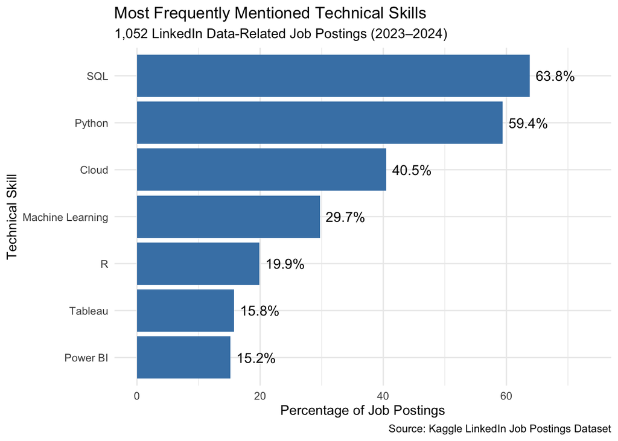

```r
# Create a horizontal bar chart of technical skill mentions

ggplot(
  technical_skill_frequency,
  aes(
    x = reorder(skill, percentage),
    y = percentage
  )
) +
  geom_col(fill = "steelblue") +
  geom_text(
    aes(label = paste0(percentage, "%")),
    hjust = -0.15,
    size = 4
  ) +
  coord_flip() +
  scale_y_continuous(
    limits = c(0, max(technical_skill_frequency$percentage) * 1.15)
  ) +
  labs(
    title = "Most Frequently Mentioned Technical Skills",
    subtitle = "1,052 LinkedIn Data-Related Job Postings (2023–2024)",
    x = "Technical Skill",
    y = "Percentage of Job Postings",
    caption = "Source: Kaggle LinkedIn Job Postings Dataset"
  ) +
  theme_minimal()
```

### 9.7 Validating Technical Skill Detection

We reviewed a sample of job descriptions to check whether our text-matching method correctly identifies technical skills.

This step is important because some technology names may appear in different contexts. We focused on verifying R and checking that our results accurately reflect technology mentions.

```r
# Review the context surrounding R matches

r_matches <- technical_skills %>%
  filter(R == TRUE) %>%
  slice_head(n = 10) %>%
  mutate(
    match_location = str_locate(description, "\\bR\\b")[, 1],

    match_context = str_sub(
      description,
      pmax(1, match_location - 60),
      match_location + 60
    )
  ) %>%
  select(job_id, match_context)

# Display the results
knitr::kable(r_matches)
```

| job_id | match_context |
| --- | --- |
| 3813645405 | ervices industries is a plusExperience with SQL, Python, or R programming languages is preferred |
| 3884435309 | perience in an analytical field using tools such as Python, R, SAS, MatlabFamiliarity with SQL or other querying language |
| 3884822884 | ch, Tensorflow, etc.) Experience with Statistical software (R, SAS, SPSS, or equivalent), and other common programming la |
| 3884844890 | t least one of the following analytical tools: SAS, Python, R Experience with visualization techniques for data analysis |
| 3884855862 | tellectually curious data engineers with a passion for the “R” in R&D. You will be part of the Data, Analytics & Technolo |
| 3884996001 | to solve specific business problems utilizing code (Python, R, Scala, etc.). Drive design and development of user classif |
| 3885828639 | esign, modeling and dynamic visualization, Proficiency with R and/or Python libraries commonly used in data science, Pyth |
| 3885834221 | gic monitoring systems.Your skills include proficiency with R and/or Python libraries commonly used in data science, Pyth |
| 3885867241 | nation of education and experienceTechnical skills: Python, R, comprehensive SQL skill, Spark, HiveSkills: Experience wit |
| 3886482728 | mputer Science, or related fieldProficiency in SQL, Python, R, or other programming languages used for data analysisExper |

### 9.8 Comparing Technical Skills Across Job Roles

We compared technical skill mentions across Data Analyst, Data Scientist, and Data Engineer job postings.

This analysis helps us understand whether certain technologies are mentioned more frequently for specific roles. We calculated percentages within each job category so the results can be compared fairly.

```r
# Match technical skills with job categories

technical_skills_by_role <- technical_skills %>%
  select(
    job_id, Python, SQL, R,
    `Machine Learning`, Tableau, `Power BI`, Cloud
  ) %>%
  left_join(
    data_jobs_clean %>%
      select(job_id, job_category),
    by = "job_id"
  ) %>%
  pivot_longer(
    cols = c(
      Python, SQL, R, `Machine Learning`,
      Tableau, `Power BI`, Cloud
    ),
    names_to = "skill",
    values_to = "mentioned"
  )

# Calculate skill frequency within each role
role_technical_summary <- technical_skills_by_role %>%
  filter(!is.na(job_category)) %>%
  group_by(job_category, skill) %>%
  summarise(
    job_count = sum(mentioned, na.rm = TRUE),
    total_jobs = n_distinct(job_id),
    percentage = round(job_count / total_jobs * 100, 1),
    .groups = "drop"
  )

# Display the results
knitr::kable(role_technical_summary)
```

| job_category | skill | job_count | total_jobs | percentage |
| --- | --- | --- | --- | --- |
| Data Analyst | Cloud | 50 | 407 | 12.3 |
| Data Analyst | Machine Learning | 54 | 407 | 13.3 |
| Data Analyst | Power BI | 80 | 407 | 19.7 |
| Data Analyst | Python | 139 | 407 | 34.2 |
| Data Analyst | R | 58 | 407 | 14.3 |
| Data Analyst | SQL | 245 | 407 | 60.2 |
| Data Analyst | Tableau | 83 | 407 | 20.4 |
| Data Engineer | Cloud | 293 | 398 | 73.6 |
| Data Engineer | Machine Learning | 82 | 398 | 20.6 |
| Data Engineer | Power BI | 51 | 398 | 12.8 |
| Data Engineer | Python | 275 | 398 | 69.1 |
| Data Engineer | R | 15 | 398 | 3.8 |
| Data Engineer | SQL | 279 | 398 | 70.1 |
| Data Engineer | Tableau | 37 | 398 | 9.3 |
| Data Scientist | Cloud | 83 | 247 | 33.6 |
| Data Scientist | Machine Learning | 176 | 247 | 71.3 |
| Data Scientist | Power BI | 29 | 247 | 11.7 |
| Data Scientist | Python | 211 | 247 | 85.4 |
| Data Scientist | R | 136 | 247 | 55.1 |
| Data Scientist | SQL | 147 | 247 | 59.5 |
| Data Scientist | Tableau | 46 | 247 | 18.6 |

### 9.9 Visualizing Technical Skills Across Job Roles

We created a grouped bar chart to compare technical skill mentions across Data Analyst, Data Scientist, and Data Engineer positions.

This visualization helps us identify which technologies are most frequently mentioned for each role and understand how technical skill requirements differ between occupations.

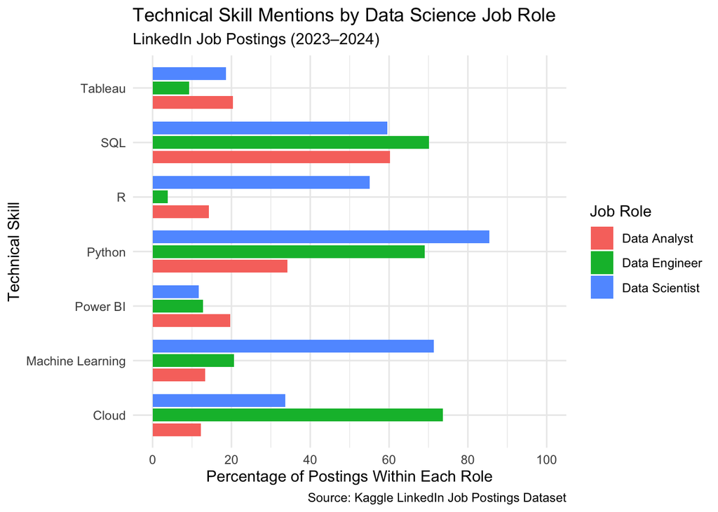

```r
# Create a grouped bar chart comparing technical skills

ggplot(
  role_technical_summary,
  aes(
    x = skill,
    y = percentage,
    fill = job_category
  )
) +
  geom_col(
    position = position_dodge(width = 0.8),
    width = 0.7
  ) +
  coord_flip() +
  scale_y_continuous(
    breaks = seq(0, 100, 20),
    limits = c(0, 100)
  ) +
  labs(
    title = "Technical Skill Mentions by Data Science Job Role",
    subtitle = "LinkedIn Job Postings (2023–2024)",
    x = "Technical Skill",
    y = "Percentage of Postings Within Each Role",
    fill = "Job Role",
    caption = "Source: Kaggle LinkedIn Job Postings Dataset"
  ) +
  theme_minimal()
```

## 10. Data Quality and Limitations

Our analysis uses LinkedIn job postings from 2023 and 2024. We selected 1,052 postings associated with Data Analyst, Data Scientist, and Data Engineer positions.

We identified technical skills by searching job descriptions for technology names. Although this approach helps us measure how frequently skills are mentioned, it does not always indicate whether a skill is required or preferred.

We also identified potential false positives when searching for the R programming language. We refined our detection method to reduce incorrect matches involving R&D.

Our findings represent the selected LinkedIn job postings rather than the entire data science job market. Because the dataset covers 2023–2024, it may not reflect current hiring trends.

```r
# Count missing and available descriptions

description_quality <- job_descriptions %>%
  summarise(
    total_records = n(),
    missing_descriptions = sum(
      is.na(description) | trimws(description) == ""
    ),
    available_descriptions = total_records - missing_descriptions
  )

knitr::kable(description_quality)
```

| total_records | missing_descriptions | available_descriptions |
| --- | --- | --- |
| 1052 | 0 | 1052 |

## 11. Comparing LinkedIn Findings with O*NET

To provide another perspective on technical skill demand, we used the O*NET Software Skills dataset as a secondary source.

We selected three occupations related to our LinkedIn job categories and examined the software technologies associated with each occupation.

Since LinkedIn and O*NET measure different aspects of skill demand, we compared the findings separately rather than treating them as equivalent measurements.

### 11.1 Importing O*NET Software Skills Data

We used the O*NET Software Skills dataset as a secondary source to compare our LinkedIn findings with occupational technology information.

We focused on data-related occupations and identify the software technologies associated with each occupation.

```r
# Download the O*NET Excel file from GitHub
onet_url <- paste0(
  "https://raw.githubusercontent.com/LBoodram26/",
  "Project-3/Data/Software%20Skills.xlsx"
)

onet_file <- tempfile(fileext = ".xlsx")
download.file(onet_url, onet_file, mode = "wb")

# Import the Excel dataset
onet_skills <- read_excel(onet_file)

# Verify the data
dim(onet_skills)
```

```
## [1] 31821     7
```

```r
names(onet_skills)
```

```
## [1] "O*NET-SOC Code"    "Title"             "Workplace Example"
## [4] "Element ID"        "Element Name"      "Hot Technology"
## [7] "In Demand"
```

```r
head(onet_skills)
```

```
## # A tibble: 6 × 7
##   `O*NET-SOC Code` Title         `Workplace Example` `Element ID` `Element Name`
##   <chr>            <chr>         <chr>               <chr>        <chr>
## 1 11-1011.00       Chief Execut… Adobe Acrobat       2.E.5.b      Document mana…
## 2 11-1011.00       Chief Execut… AdSense Tracker     2.E.6.f      Data base use…
## 3 11-1011.00       Chief Execut… Atlassian JIRA      2.E.5.a      Content workf…
## 4 11-1011.00       Chief Execut… Blackbaud The Rais… 2.E.6.c      Customer rela…
## 5 11-1011.00       Chief Execut… ComputerEase const… 2.E.2.a      Accounting so…
## 6 11-1011.00       Chief Execut… Database reporting… 2.E.6.e      Data base rep…
## # ℹ 2 more variables: `Hot Technology` <chr>, `In Demand` <chr>
```

### 11.2 Filtering O*NET Occupations

We filtered the O*NET Software Skills dataset to focus on occupations related to our LinkedIn job categories.

We selected Data Scientists, Business Intelligence Analysts, and Database Architects to compare their associated software technologies.

Although these occupations are related to our research, they are not all exact matches to the LinkedIn job titles.

```r
# Select the O*NET occupations relevant to our project

onet_filtered <- onet_skills %>%
  filter(
    `O*NET-SOC Code` %in% c(
      "15-2051.00",
      "15-2051.01",
      "15-1243.00"
    )
  )

# Count software entries for each occupation
onet_occupation_summary <- onet_filtered %>%
  count(
    `O*NET-SOC Code`,
    Title,
    name = "software_count"
  )

# Display the results
knitr::kable(onet_occupation_summary)
```

| O*NET-SOC Code | Title | software_count |
| --- | --- | --- |
| 15-1243.00 | Database Architects | 322 |
| 15-2051.00 | Data Scientists | 87 |
| 15-2051.01 | Business Intelligence Analysts | 203 |

```r
# Confirm the total filtered records
nrow(onet_filtered)
```

```
## [1] 612
```

### 11.3 Identifying Technical Skills in O*NET

We examined the software technologies listed in O*NET for Data Scientists, Business Intelligence Analysts, and Database Architects.

We looked for technologies related to Python, SQL, R, machine learning, Tableau, Power BI, and cloud platforms.

This analysis helps us compare our LinkedIn findings with an independent occupational data source.

```r
# Define technology search patterns
onet_patterns <- c(
  Python = "\\bpython\\b",
  SQL = "\\bsql\\b",
  R = "\\bR\\b",
  `Machine Learning` = "machine learning",
  Tableau = "tableau",
  `Power BI` = "power\\s*bi",
  Cloud = "\\b(aws|azure|google cloud|gcp)\\b"
)

# Search O*NET software examples for these technologies
onet_technical_skills <- onet_filtered %>%
  mutate(
    software_name = replace_na(`Workplace Example`, ""),
    Python = str_detect(
      software_name,
      regex(onet_patterns["Python"], ignore_case = TRUE)
    ),
    SQL = str_detect(
      software_name,
      regex(onet_patterns["SQL"], ignore_case = TRUE)
    ),
    R = str_detect(
      software_name,
      "\\bR\\b"
    ),
    `Machine Learning` = str_detect(
      software_name,
      regex(onet_patterns["Machine Learning"], ignore_case = TRUE)
    ),
    Tableau = str_detect(
      software_name,
      regex(onet_patterns["Tableau"], ignore_case = TRUE)
    ),
    `Power BI` = str_detect(
      software_name,
      regex(onet_patterns["Power BI"], ignore_case = TRUE)
    ),
    Cloud = str_detect(
      software_name,
      regex(onet_patterns["Cloud"], ignore_case = TRUE)
    )
  )

# Display the matching software entries
onet_matches <- onet_technical_skills %>%
  pivot_longer(
    cols = c(
      Python, SQL, R, `Machine Learning`,
      Tableau, `Power BI`, Cloud
    ),
    names_to = "technical_skill",
    values_to = "mentioned"
  ) %>%
  filter(mentioned) %>%
  select(
    Title,
    `Workplace Example`,
    technical_skill,
    `In Demand`
  )

knitr::kable(head(onet_matches, 20))
```

| Title | Workplace Example | technical_skill | In Demand |
| --- | --- | --- | --- |
| Database Architects | Amazon Web Services AWS CloudFormation | Cloud | N |
| Database Architects | Amazon Web Services AWS software | Cloud | Y |
| Database Architects | Data Recovery Software SQL Server Data Recovery | SQL | N |
| Database Architects | Micosoft SQL Server Analysis Services SSAS | SQL | N |
| Database Architects | Microsoft Azure software | Cloud | Y |
| Database Architects | Microsoft Power BI | Power BI | Y |
| Database Architects | Microsoft SQL Server | SQL | N |
| Database Architects | Microsoft SQL Server Integration Services SSIS | SQL | N |
| Database Architects | Microsoft SQL Server Reporting Services SSRS | SQL | N |
| Database Architects | Oracle PL/SQL | SQL | N |
| Database Architects | Oracle SQL Developer | SQL | N |
| Database Architects | Oracle SQL Loader | SQL | N |
| Database Architects | Oracle SQL Plus | SQL | N |
| Database Architects | Python | Python | Y |
| Database Architects | Quest SQL Optimizer for Oracle | SQL | N |
| Database Architects | R | R | N |
| Database Architects | Redgate SQL Server | SQL | N |
| Database Architects | SentryOne SQL Sentry | SQL | N |
| Database Architects | Structured query language SQL | SQL | Y |
| Database Architects | Tableau | Tableau | Y |

### 11.4 Summarizing O*NET Technical Skills

We summarized the technologies identified in O*NET for the three selected occupations.

We examined which technologies are listed for each occupation and how many matching software entries are identified as in demand.

This provides an independent comparison with our LinkedIn job posting analysis.

```r
# Summarize O*NET technology matches by occupation

onet_skill_summary <- onet_matches %>%
  group_by(Title, technical_skill) %>%
  summarise(
    software_entries = n_distinct(`Workplace Example`),
    in_demand_entries = n_distinct(
      `Workplace Example`[`In Demand` == "Y"]
    ),
    .groups = "drop"
  ) %>%
  arrange(Title, desc(in_demand_entries))

# Display the summary
knitr::kable(onet_skill_summary)
```

| Title | technical_skill | software_entries | in_demand_entries |
| --- | --- | --- | --- |
| Business Intelligence Analysts | Cloud | 2 | 2 |
| Business Intelligence Analysts | Power BI | 1 | 1 |
| Business Intelligence Analysts | Python | 1 | 1 |
| Business Intelligence Analysts | R | 1 | 1 |
| Business Intelligence Analysts | SQL | 7 | 1 |
| Business Intelligence Analysts | Tableau | 1 | 1 |
| Data Scientists | Cloud | 4 | 2 |
| Data Scientists | Power BI | 1 | 1 |
| Data Scientists | Python | 1 | 1 |
| Data Scientists | R | 1 | 1 |
| Data Scientists | SQL | 2 | 1 |
| Data Scientists | Tableau | 1 | 1 |
| Database Architects | Cloud | 3 | 2 |
| Database Architects | Power BI | 1 | 1 |
| Database Architects | Python | 1 | 1 |
| Database Architects | SQL | 14 | 1 |
| Database Architects | Tableau | 1 | 1 |
| Database Architects | R | 1 | 0 |

### 11.5 Comparing LinkedIn and O*NET Findings

We compared the technical skills identified in LinkedIn job descriptions with technologies identified in O*NET.

LinkedIn measures how frequently skills are mentioned in our sample of job postings, while O*NET identifies software technologies associated with occupations and indicates whether individual technologies are classified as in demand.

We used O*NET as a secondary reference rather than directly comparing its software-entry counts with LinkedIn percentages.

```r
# Summarize whether O*NET identifies in-demand software
# in each selected technical skill group

onet_comparison <- onet_skill_summary %>%
  group_by(technical_skill) %>%
  summarise(
    occupations_listed = n_distinct(Title),
    occupations_in_demand = n_distinct(
      Title[in_demand_entries > 0]
    ),
    .groups = "drop"
  )

# Combine with LinkedIn technical skill percentages
comparison_table <- technical_skill_frequency %>%
  left_join(
    onet_comparison,
    by = c("skill" = "technical_skill")
  ) %>%
  mutate(
    occupations_listed = replace_na(
      occupations_listed, 0L
    ),
    occupations_in_demand = replace_na(
      occupations_in_demand, 0L
    )
  ) %>%
  arrange(desc(percentage))

# Display comparison
knitr::kable(
  comparison_table,
  col.names = c(
    "Technical Skill",
    "LinkedIn Job Count",
    "LinkedIn %",
    "O*NET Occupations Listed",
    "O*NET Occupations In Demand"
  )
)
```

| Technical Skill | LinkedIn Job Count | LinkedIn % | O*NET Occupations Listed | O*NET Occupations In Demand |
| --- | --- | --- | --- | --- |
| SQL | 671 | 63.8 | 3 | 3 |
| Python | 625 | 59.4 | 3 | 3 |
| Cloud | 426 | 40.5 | 3 | 3 |
| Machine Learning | 312 | 29.7 | 0 | 0 |
| R | 209 | 19.9 | 3 | 2 |
| Tableau | 166 | 15.8 | 3 | 3 |
| Power BI | 160 | 15.2 | 3 | 3 |

## 12. Findings and Conclusions

### 12.1 Main Findings

The goal of this project was to understand which technical skills are most frequently mentioned in data-related job postings and whether those skills differ across job roles.

We analyzed 1,052 LinkedIn job postings from 2023 and 2024, focusing on Data Analyst, Data Scientist, and Data Engineer positions.

SQL was the most common technical skill overall, appearing in 63.8% of postings and in at least 59% of postings for each job role. Cloud technologies stood out in Data Engineer postings (73.6%), compared with Data Scientist (33.6%) and Data Analyst (12.3%) postings.

Python (85.4%) and machine learning (71.3%) were mentioned more frequently than R (55.1%) in Data Scientist postings. R was mentioned less frequently in Data Analyst (14.3%) and Data Engineer (3.8%) postings.

### 12.2 O*NET Comparison

We used the O*NET Software Skills dataset as a second source to compare our findings.

O*NET identified SQL, Python, Tableau, Power BI, and cloud technologies as having in-demand software entries across the three occupations we selected.

Although O*NET measures occupational software associations rather than the percentage of job postings, it provided additional context for our LinkedIn findings.

### 12.3 Limitations

For the O*NET comparison, we selected occupations that were closely related to our LinkedIn job categories, but they were not all exact matches. Additionally, our technology matching method may not identify every relevant software product, particularly those used for machine learning.

Our analysis was based on a selected group of LinkedIn job postings from 2023 and 2024, so the results may not represent all employers or current hiring trends.

We identified skills through text matching, which means some references could be missed or incorrectly identified. We also measured skill mentions rather than confirming whether a technology was required or preferred.

### 12.4 Conclusion

Based on our analysis, SQL and Python were the most frequently mentioned technical skills overall. However, different job roles emphasized different technologies.

These findings suggest that people entering the data field should consider the requirements of their intended role when deciding which technical skills to develop.

```r
dbDisconnect(con)
```

## 13. References

ArcGIS StoryMaps. (n.d.). *Using satellite information to understand & model landslide.* https://storymaps.arcgis.com/stories/61c6100d40bd47749e435e79bd54f480

Kaggle. (n.d.). *LinkedIn job postings (2023–2024)* [Data set]. https://www.kaggle.com/datasets/arshkon/linkedin-job-postings

National Center for O*NET Development. (n.d.). *In-demand technology skills: Data scientists.* O*NET OnLine. https://www.onetonline.org/link/demand/15-2051.00

National Center for O*NET Development. (n.d.). *O*NET database.* https://www.onetcenter.org/database.html

R Core Team. (n.d.). *The R project for statistical computing.* https://www.r-project.org/

SQLite. (n.d.). *SQLite documentation.* https://www.sqlite.org/docs.html

Wickham, H., François, R., Henry, L., Müller, K., & Vaughan, D. (n.d.). *dplyr: A grammar of data manipulation.* https://dplyr.tidyverse.org/

Wickham, H. (n.d.). *ggplot2: Create elegant data visualisations using the grammar of graphics.* https://ggplot2.tidyverse.org/

RSQLite contributors. (n.d.). *RSQLite: SQLite interface for R.* https://rsqlite.r-dbi.org/